# COMPSCIX 415.2 Homework 6

Emerson Sosa

3/9/2019

# 1 Exercise 1

*1. What variables are in this data set?*

There are three variables in the Whickham dataset.

*2. How many observations are there and what does each represent?*

There are 1,314 observations in the Whickham data set where ‘outcome’ = survival status after 20 years with two factors: Alive, Dead; ‘smoker’ = smoking status at baseline with two factors: No, Yes; ‘age’ = age in years at the time of the first survey.

*3. Create a table (use the R code below as a guide) and a visualization of the relationship between smoking status and outcome, ignoring age. What do you see? Does it make sense?*

It does not make sense because one would assume that if one is a smoker, there is a higher probablity of death. The opposite is true.

```r
library(tidyverse)
library(mosaicData)
(data(Whickham))
```

```
## [1] "Whickham"
```

```r
glimpse(Whickham)
```

```
## Observations: 1,314
## Variables: 3
## $ outcome <fct> Alive, Alive, Dead, Alive, Alive, Alive, Alive, Dead, Al…
## $ smoker  <fct> Yes, Yes, Yes, No, No, Yes, Yes, No, No, No, No, Yes, No…
## $ age     <int> 23, 18, 71, 67, 64, 38, 45, 76, 28, 27, 28, 34, 20, 72, …
```

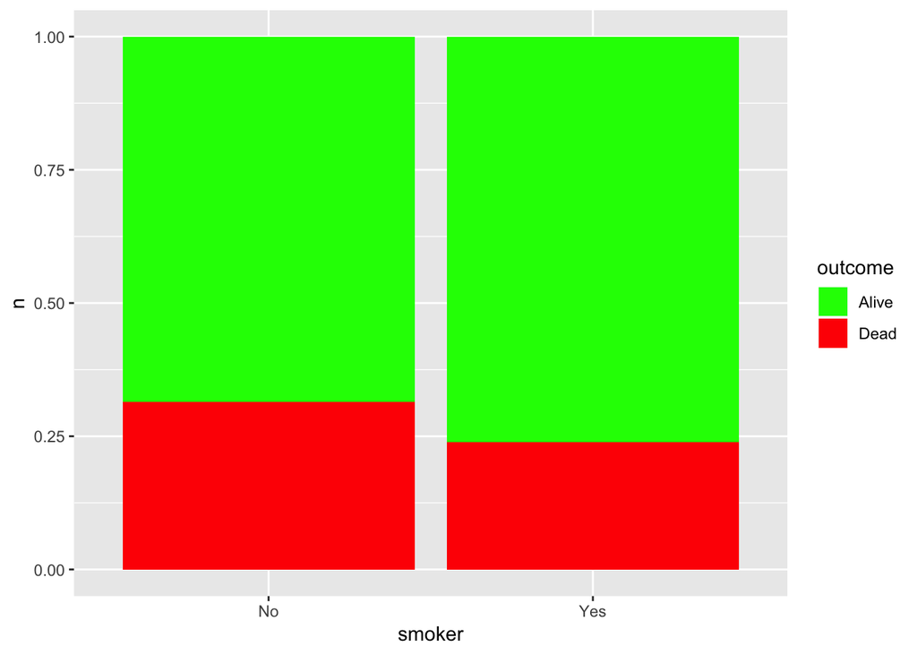

```r
Whickham.counts <- Whickham %>%
  count(smoker, outcome)



Whickham.counts %>%
  ggplot() + geom_bar(aes(x = smoker, y = n, fill = outcome), stat = 'identity', position = 'fill') +
  scale_fill_manual(values=c("green", "red"))
```

*4. Recode the age variable into an ordered factor with three categories: age <= 44, age > 44 & age <= 64, and age > 64. Now, recreate visualization from above, but facet on your new age factor. What do you see? Does it make sense?*

The results are definitely intuitive as cancer is most lethal in older age. The younger cohorts pull the above graph towards a more biased “alive” representation.

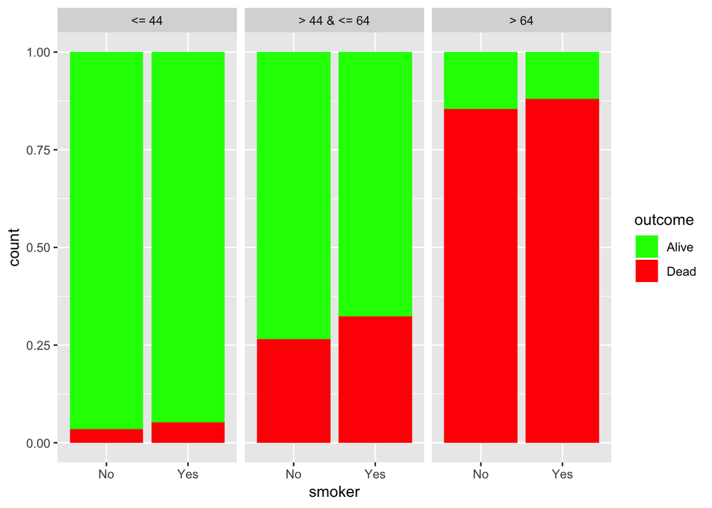

```r
age <- Whickham %>%
  select(age)
age.cat <- case_when(age <= 44 ~ '<= 44',
                      age > 44  & age <= 64 ~ '> 44 & <= 64',
                      age > 64 ~ '> 64')

age.fact <- factor(age.cat, ordered = TRUE)

Whickham <- Whickham %>%
  mutate(age.fact)



Whickham %>%
  ggplot() + geom_bar(aes(x = smoker, fill = outcome), position = 'fill') +
  facet_wrap(age.fact) +
  scale_fill_manual(values=c("green", "red"))
```

# 2 Exercise 2

*1. Generate a random sample of size n = 10000 from a gamma(1,2) distribution and plot a histogram or density curve. Use the code below to help you get your sample.*

`library(tidyverse)` `n <- 10000` `gamma_samp <- tibble(x = rgamma(n, shape = 1, scale = 2))`

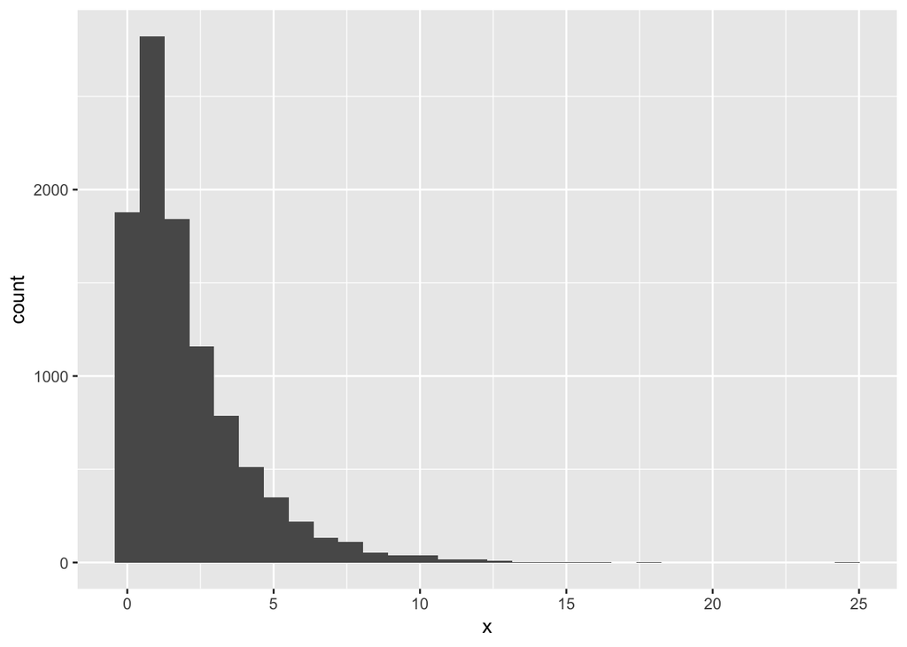

```r
n <- 10000
gamma.samp <- tibble(x = rgamma(n, shape =1, scale = 2))

ggplot(gamma.samp) +
  geom_histogram(aes(x))
```

*2.What is the mean and standard deviation of your sample? They should both be close to 2 because for a gamma distribution:* *mean = shape x scale* *variance = shape x scale^2*

```r
values.x <- gamma.samp %>%
  select(x)

mean(gamma.samp$x)
```

```
## [1] 2.016861
```

```r
sd(gamma.samp$x)
```

```
## [1] 2.041011
```

`mean_samp <- gamma_samp %>% .[['x']] %>% mean()`

*3.Pretend the distribution of our population of data looks like the plot above. Now take a sample of size n = 30 from a Gamma(1,2) distribution, plot the histogram or density curve, and calculate the mean and standard deviation.*

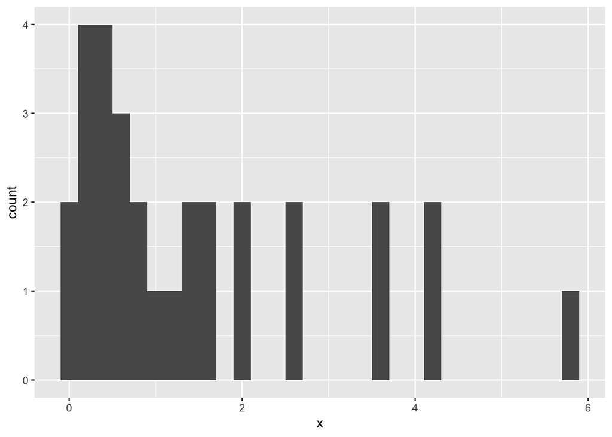

```r
just.30 <- gamma.samp %>%
  sample_n(30)


ggplot(just.30) +
  geom_histogram(aes(x))
```

```r
mean(just.30$x)
```

```
## [1] 1.498248
```

```r
sd(just.30$x)
```

```
## [1] 1.488881
```

*4.Take a sample of size n = 30, again from the Gamma(1,2) distribution, calculate the mean, and assign it to a vector named mean_samp. Repeat this 10000 times!!!! The code below might help.*

```r
gamma.samp <- tibble(x = rgamma(n, shape =1, scale = 2))
gamma.samp
```

```
## # A tibble: 10,000 x 1
##        x
##    <dbl>
##  1 0.405
##  2 0.795
##  3 0.355
##  4 1.99
##  5 0.572
##  6 0.728
##  7 0.313
##  8 1.32
##  9 0.595
## 10 0.564
## # … with 9,990 more rows
```

```r
mean.samp <- mean(gamma.samp$x, na.rm = TRUE)

mean_samp <- rep(NA, 10000)
for(i in 1:10000) {
  g_samp <- rgamma(30, shape = 1, scale = 2)
  mean_samp[i] <- mean(g_samp)
}
mean_samp <- tibble(mean_samp)
mean_samp
```

```
## # A tibble: 10,000 x 1
##    mean_samp
##        <dbl>
##  1      2.26
##  2      2.28
##  3      2.39
##  4      1.93
##  5      1.44
##  6      2.19
##  7      1.81
##  8      2.73
##  9      2.10
## 10      2.37
## # … with 9,990 more rows
```

*5.Make a histogram of your collection of means from above (mean_samp).*

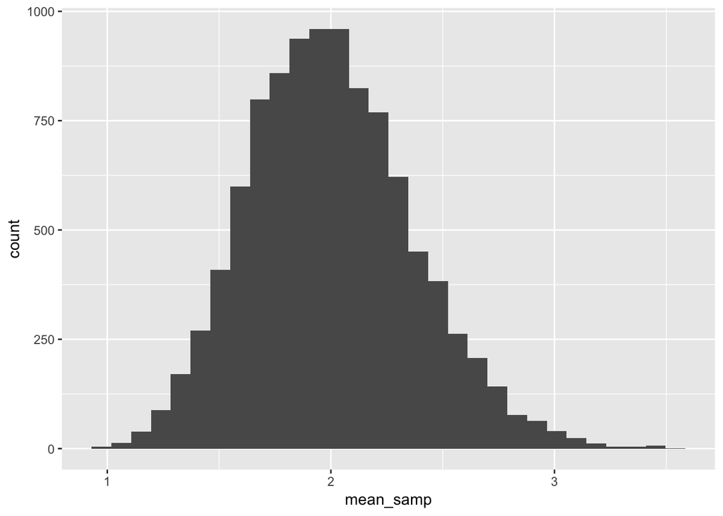

```r
mean_samp %>%
  ggplot() +
  geom_histogram(aes(mean_samp))
```

*6.Calculate the mean and standard deviation of all of your sample means.*

```r
mean(mean_samp$mean_samp)
```

```
## [1] 1.999755
```

```r
sd(mean_samp$mean_samp)
```

```
## [1] 0.3667784
```

*7.Did anything surprise you about your answers to #6?*

The opposite happened for me as the smaller standard deviation shows that the sample of means when wrung through the standard deviation formula shows that the data got tighter; a smaller SD means that there is less variation in the data, which is what we wanted out of a sample of means.

```r
mean_samp <- rep(NA, 10000)
for(i in 1:10000) {
  g_samp <- rgamma(300, shape = 1, scale = 2)
  mean_samp[i] <- mean(g_samp)
}
mean_samp <- tibble(mean_samp)

mean(mean_samp$mean_samp)
```

```
## [1] 2.001831
```

```r
sd(mean_samp$mean_samp)
```

```
## [1] 0.1159566
```